# curatedOvarianData meta-clustering with 200 (meta-rank) features using kmeans consensus

It turns out "GSEABase” isn't all that great..so just using some Broad gene sets I already downloaded and the standard hypergeometric tests:

```r
GSEA_out <- GSEA(testGeneVector=rownames(metaMatrix),method=c("hypergeometric","fisher"),genomeSize=20000,
                  refGeneListDir="/home/data/MSigDB/GSEA_base_MSigDB_lists_merged.RData.gzip")
```

```
##
## Using default MSigDB lists: MSigDB_onco_symbols, MSigDB_CanPath_symbols,MSigDB_TFT_symbols,MSigDB_immun_symbols,
##        and MSigDB_cancerNeigh_symbols.
```

```r
message("Gene lists enriched with q-value below .05:")
```

```
## Gene lists enriched with q-value below .05:
```

```r
load("/home/data/MSigDB/GSEA_base_MSigDB_lists_merged.RData.gzip")
names(GSEA_base_MSigDB_lists_merged)[which(GSEA_out$qvalues<=.05)]
```

```
##   [1] "E2F1_UP.V1_DN"
##   [2] "EGFR_UP.V1_UP"
##   [3] "HINATA_NFKB_MATRIX"
##   [4] "VEGF_A_UP.V1_UP"
##   [5] "ATF2_S_UP.V1_DN"
##   [6] "WNT_UP.V1_UP"
##   [7] "RELA_DN.V1_DN"
##   [8] "P53_DN.V1_DN"
##   [9] "P53_DN.V1_UP"
##  [10] "SNF5_DN.V1_DN"
##  [11] "LTE2_UP.V1_DN"
##  [12] "MEK_UP.V1_DN"
##  [13] "RAF_UP.V1_DN"
##  [14] "PRC1_BMI_UP.V1_DN"
##  [15] "ESC_J1_UP_LATE.V1_UP"
```

[output cut: 175 more lines]

**Survival Analyses** I'm still working on determing which long-term and binary variables have the least amount of NAs across the samples in these meta-clusters, but it does look like the binary vital_status variable (alive or dead) and continous days to death variables provide survival curves that significantly stratify patients. It was less significant when I used a 5-year cutoff.

```r
 library("survival")
 #already have esets loaded:
 #load("/home/kplaney/ovarian_analysis/esets_proc_TCGAcombat.RData.gzip")
 phenoMasterDF <- createPhenoMasterTableFromMatrixList(esetList=esets)
```

```
 ## This function assumes samples/patient clinical data rows are not duplicated
```

```r
 #save(phenoMasterDF,file="/home/kplaney/ovarian_analysis/curatedOvarian_phenoMasterDF.RData.gzip",compress="gzip")
 #load("/home/kplaney/ovarian_analysis/curatedOvarian_phenoMasterDF.RData.gzip")
 #study numbers won't align here because some filtered out (had no robust clusters); need to "translate"

 origToNewIndexMap <- data.frame(origToNewIndexMap,stringsAsFactors=FALSE)
 colnames(origToNewIndexMap) <- c("studyNum","origStudyNum")
 sampleClustCommKey <- join(sampleClustCommKey,origToNewIndexMap,by="studyNum",type="full",match="all")
 sampleClustCommPhenoData <- addClinicalVarToNodeAttributes(sampleClustCommKey,phenoMasterDF=phenoMasterDF)

 #survival analysis
 outcomesVarBinary="vital_status"
 outcomesVarCont = "days_to_death"
 CutoffPointYears=5
 uniquePatientID="unique_patient_ID"
 groupingTerm="community"


  #only take samples with the groupingTerm you're looking at.
  sampleClustCommPhenoData <- sampleClustCommPhenoData[which(!is.na(sampleClustCommPhenoData[, groupingTerm])), ]
  #remove samples with NA values.
  groupings <- sampleClustCommPhenoData[, groupingTerm]

  #groupings <- groupings[which(!is.na(sampleClustCommPhenoData[,outcomesVarBinary]))];
  #outcomesData <- sampleClustCommPhenoData[which(!is.na(sampleClustCommPhenoData[,outcomesVarBinary])),];

  #keep samples with NA days to event for now?
 #hmm...one meta-cluster is left out if use "days_to_death"...
  #groupings <- as.numeric(as.factor(groupings[which(!is.na(outcomesData[,outcomesVarCont]))]))
  #outcomesData <- outcomesData[which(!is.na(outcomesData[,outcomesVarCont])),];

  #if binary is character string categories: make it a factor first, then numeric,
  #otherwise coxph function will throw errors.
 #  nonCensoredTerm=1
 sampleClustCommPhenoData[which(sampleClustCommPhenoData[ ,outcomesVarBinary]=="deceased"),outcomesVarBinary] <- 1
 sampleClustCommPhenoData[which(sampleClustCommPhenoData[ ,outcomesVarBinary]=="living"),outcomesVarBinary] <- 0
  outcomesDataShort <- data.frame(as.numeric(sampleClustCommPhenoData[,outcomesVarBinary]),as.numeric(sampleClustCommPhenoData[,outcomesVarCont])
  );

  #sometimes the names are duplicated across studies - remove this line
  #rownames(outcomesDataShort ) <- outcomesData[,uniquePatientID];
  colnames(outcomesDataShort) <- c("Censoring","TimeToLastContactOrEvent")

  nonCensoredTerm=1
  censoredTerm=0
  Survival <- outcomesDataShort
  #creating the survival objects with the time and censoring variables
  OverallSurvival <- Surv(Survival$TimeToLastContactOrEvent,Survival$Censoring==nonCensoredTerm);
  #creating a survival object cutoff at a certain point
   CutoffPoint <- CutoffPointYears*365;
   CutoffSamples=Survival$TimeToLastContactOrEvent>CutoffPoint & !is.na(Survival$TimeToLastContactOrEvent)
   SurvivalCutoff=Survival
   SurvivalCutoff$TimeToLastContactOrEvent[CutoffSamples]=CutoffPoint
   SurvivalCutoff$Censoring[CutoffSamples]=censoredTerm
 #   #"Surv" creates a survival object. really for binary outcomes data.
   OverallSurvivalCutoff=Surv(SurvivalCutoff$TimeToLastContactOrEvent,SurvivalCutoff$Censoring==nonCensoredTerm)

    coxfit=coxph(OverallSurvival~groupings, data=Survival)
  message("coxfit summary for overall survival.")
```

```
 ## coxfit summary for overall survival.
```

```r
  summary(coxfit)
```

```
 ## Call:
 ## coxph(formula = OverallSurvival ~ groupings, data = Survival)
 ##
 ##   n= 1324, number of events= 717
 ##    (517 observations deleted due to missingness)
 ##
 ##               coef exp(coef) se(coef)      z Pr(>|z|)
 ## groupings -0.14661   0.86363  0.05788 -2.533   0.0113 *
 ## ---
 ## Signif. codes:  0 '***' 0.001 '**' 0.01 '*' 0.05 '.' 0.1 ' ' 1
 ##
 ##           exp(coef) exp(-coef) lower .95 upper .95
 ## groupings    0.8636      1.158     0.771    0.9674
 ##
 ## Concordance= 0.527  (se = 0.011 )
 ## Rsquare= 0.005   (max possible= 0.999 )
 ## Likelihood ratio test= 6.66  on 1 df,   p=0.009844
 ## Wald test            = 6.42  on 1 df,   p=0.01131
 ## Score (logrank) test = 6.41  on 1 df,   p=0.01133
```

```r
  #plot(cox.zph(coxfit))
 kmfit=survdiff(OverallSurvival ~ groupings)
 message("kaplan meier p-value for overall survival:")
```

```
 ## kaplan meier p-value for overall survival:
```

```r
 1 - pchisq(kmfit$chisq, length(kmfit$n) - 1)
```

```
 ## [1] 0.0006151971
```

```r
 message("calculating the sign of the survival relationship")
```

```
 ## calculating the sign of the survival relationship
```

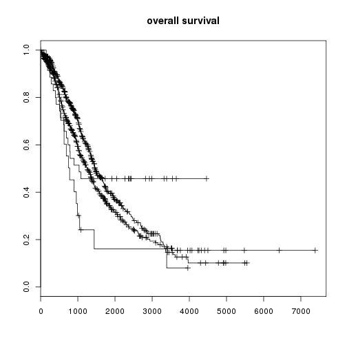

```r
  mfit=survfit(OverallSurvival ~ groupings)
  plot(mfit,main="overall survival")
```

```r
  coxfit=coxph(OverallSurvivalCutoff~groupings, data= SurvivalCutoff)
  message("coxfit summary for survival cutoff at ",CutoffPointYears,"years:")
```

```
 ## coxfit summary for survival cutoff at 5years:
```

```r
  summary(coxfit)
```

```
 ## Call:
 ## coxph(formula = OverallSurvivalCutoff ~ groupings, data = SurvivalCutoff)
 ##
 ##   n= 1324, number of events= 622
 ##    (517 observations deleted due to missingness)
 ##
 ##               coef exp(coef) se(coef)      z Pr(>|z|)
 ## groupings -0.09497   0.90940  0.06268 -1.515     0.13
 ##
 ##           exp(coef) exp(-coef) lower .95 upper .95
 ## groupings    0.9094        1.1    0.8043     1.028
 ##
 ## Concordance= 0.526  (se = 0.011 )
 ## Rsquare= 0.002   (max possible= 0.998 )
 ## Likelihood ratio test= 2.35  on 1 df,   p=0.1253
 ## Wald test            = 2.3  on 1 df,   p=0.1297
 ## Score (logrank) test = 2.29  on 1 df,   p=0.1298
```

```r
 #plot(cox.zph(coxfit))

  kmfit=survdiff(OverallSurvivalCutoff ~ groupings)
 message("kaplan meier p-value for survival cutoff:")
```

```
 ## kaplan meier p-value for survival cutoff:
```

```r
  1 - pchisq(kmfit$chisq, length(kmfit$n) - 1)
```

```
 ## [1] 0.0004601185
```

```r
 message("a chi-square test looking at the binary recurrence status variable, as this data was recorded at least in some patients in all 4 meta-clusters:")
```

```
 ## a chi-square test looking at the binary recurrence status variable, as this data was recorded at least in some patients in all 4 meta-clusters:
```

```r
 chisq.test(sampleClustCommPhenoData[,"recurrence_status"],groupings)
```

```
 ##
 ##     Pearson's Chi-squared test
 ##
 ## data:  sampleClustCommPhenoData[, "recurrence_status"] and groupings
 ## X-squared = 19.6412, df = 3, p-value = 0.0002014
```

```r
 message("We see a trend by just tabling the recurrence status variable too, but it's still pretty 50-50 (for the samples that didn't have NA values; it looks like a lot of samples were still missing this variable from certain meta-clusters")
```

```
 ## We see a trend by just tabling the recurrence status variable too, but it's still pretty 50-50 (for the samples that didn't have NA values; it looks like a lot of samples were still missing this variable from certain meta-clusters
```

```r
 table(sampleClustCommPhenoData[,"recurrence_status"],groupings)
```

```
 ##               groupings
 ##                  3   4   5   6
 ##   norecurrence 172 225  16  38
 ##   recurrence   341 365  16  25
```